# Potencias y Raíces

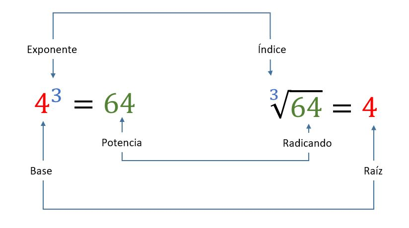

### 1. Potenciación

Una **potencia** es una forma abreviada de escribir una multiplicación de factores iguales.

#### Ejemplos:

$2 \cdot 2 \cdot 2 = 2^3 = 8$

$5 \cdot 5 = 5^2 = 25$

En una potencia:

- La **base** es el número que se repite.
- El **exponente** indica cuántas veces se multiplica la base por sí misma.

$2^3$ Se lee: *“dos elevado a la tercera”* o *“dos al cubo”*.

Si necesitas repasar, puedes ver este video: [Potencias](https://www.youtube.com/watch?v=2lWEs7dEgWQ).

#### Ejercicios

**a)** Calcula la potencia: Por ejemplo $6^2 = 6 \cdot 6 = 36$

1. $3^2$
2. $2^5$
3. $10^3$
4. $4^3$
5. $6^3$

**b)** Completa con el número correcto

1. $5^2=\underline{\hspace{0.6cm}}$
2. $\underline{\hspace{0.6cm}}^3=27$
3. $10^2 = \underline{\hspace{0.6cm}}$
4. $\underline{\hspace{0.6cm}}^2 = 49$
5. $5^X = 125$ → ¿qué exponente debe ir en X?

### 2. Raíces cuadradas

La **raíz cuadrada** de un número es el valor que, multiplicado por sí mismo, da ese número.

#### Ejemplo

$\sqrt{25}=5$

porque:

$5 \cdot 5 = 25$

Otros ejemplos:

- $\sqrt{9}=3$
- $\sqrt{36}=6$
- $\sqrt{100}=10$

La raíz cuadrada es la operación inversa de elevar al cuadrado.

Si necesitas repasar, puedes ver este video: [Raíces cuadradas](https://www.youtube.com/watch?v=TX2idjNEiFw).

#### Ejercicios

**a)** Calcula:

1. $\sqrt{16}$
2. $\sqrt{49}$
3. $\sqrt{64}$
4. $\sqrt{81}$

**b)** Completa la línea con un número:

1. $\sqrt{\underline{\hspace{0.6cm}}}=8$
2. $\sqrt{\underline{\hspace{0.6cm}}}=12$
3. $\sqrt{121}=\underline{\hspace{0.6cm}}$

### 3. Problemas desafiantes

(Son opcionales, no es obligatorio hacerlos pero son una buena oportunidad para ejercitar y potenciar el pensamiento, también ayudan a aumentar la nota final)

**1)** La leyenda cuenta que el rey del lugar donde se inventó el ajedrez quizo premiar al inventor. Para asombro del rey este le pidió una recompensa muy sencilla: llevarse la cantidad total de granos de trigo que resultase de poner uno en la primera casilla del tablero, dos en la segunda, cuatro en la tercera, ocho en la cuarta y así sucesivamente, siempre duplicando la cantidad de la casilla anterior. El rey pensó que era fácil pagar pero luego al calcular se dió cuenta de que era practicamente imposible juntar esa cantidad…

Vamos a analizar este problema usando potencias de 2, observa las cantidades de granos que llevan las primeras casillas y las correspondientes potencias:

- 1° casilla: 1 grano → $1=2^0$
- 2° casilla: 2 granos → $2=2^1$
- 3° casilla: 4 granos → $4=2^2$
- 4° casilla: 8 granos → $8=2^3$

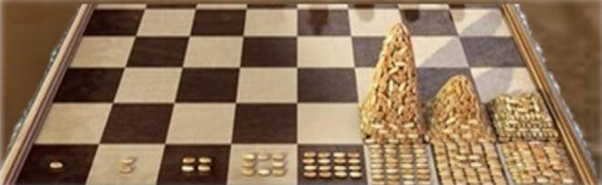

Fuente: Chess.com

*Problema:* **a)** Siguiendo este patrón, escribe mediante una potencia cuántos granos de trigo habría en la casilla número 25. No es necesario calcular el resultado (es un número bien grande); basta con expresar la cantidad usando una base y un exponente. **b)** Expresa como potencia y calcula (aquí sí calcula) cuantos granos van en la casilla número 12.

**2)** En una antigua biblioteca, Benjamín encuentra un cofre con un acertijo:

*“El número secreto es la raíz cuadrada de un número de tres cifras. Si elevás el número secreto al cuadrado y le sumás 4, da 125.”*

Benjamín piensa un rato y escribe la respuesta correcta.

*Problema:* ¿Cuál es el número secreto? Utiliza potencias y raíces para representar la situación antes de resolverla.

**Autocorrección**

El objetivo es aprender también de los errores. Al terminar, activa las respuestas y autocorrige:

- Bien: **✓**
- Mal: corrige y marca **✓✓**

Hay que presentar autocorregidos los ejercicios pedidos en las alternancias.

**Clic aquí** para ver las respuestas**

##### 1. Potenciación

**a)** Calcula la potencia

1. 9
2. 32
3. 1000
4. 64
5. 216

**b)** Completa con el número correcto

1. 25
2. 3
3. 100
4. 7
5. 3

##### 2. Raíces cuadradas

**a)** Calcula:

1. 4
2. 7
3. 8
4. 9

**b)** Completa la línea con un número:

1. 64
2. 144
3. 11

##### 3. Problemas desafiantes

Se muestran en clase